# Reproducible Data Analysis Project

```r
car::durbinWatsonTest(fit)
```

```
##  lag Autocorrelation D-W Statistic p-value
##    1       0.3508181      1.108522   0.006
##  Alternative hypothesis: rho != 0
```

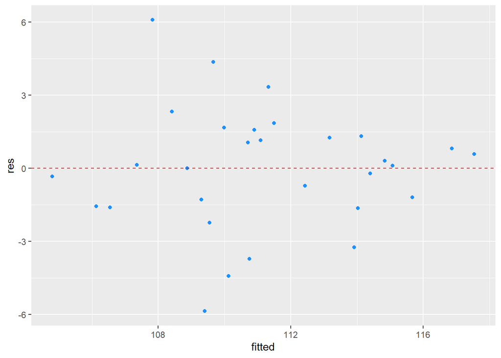

```r
res <- residuals(fit)
fitted <- predict(fit)

ggplot(data = NULL, aes(x = fitted, y = res)) +
geom_point(colour = "dodgerblue") +
geom_hline(yintercept = 0, colour = "red", linetype = "dashed")
```

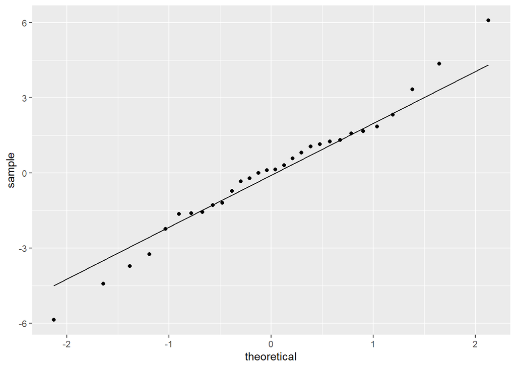

```r
ggplot(data = NULL, aes(sample = res)) +
stat_qq() + stat_qq_line()
```

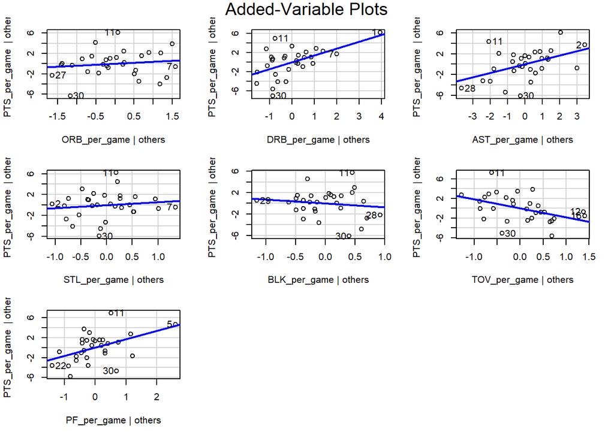

```r
car::avPlots(fit)
```

```r
sqrt(car::vif(fit))
```

```
## ORB_per_game DRB_per_game AST_per_game STL_per_game BLK_per_game TOV_per_game
##     1.098324     1.581091     1.342292     1.472191     1.558341     1.525588
##  PF_per_game
##     1.696399
```

We can now create player variables to determine the 5 starting players to select. To do this we can first create per game values and then apply the model to view the outcome.

```r
team_mins_per_game <- nba_team_stats2 %>%
  dplyr::group_by(Team) %>%
  dplyr::summarise(team_mins_per_game = MP/max(G)) %>%
  pull(team_mins_per_game) %>%
  mean
team_mins_per_game
```

```
## [1] 241.6463
```

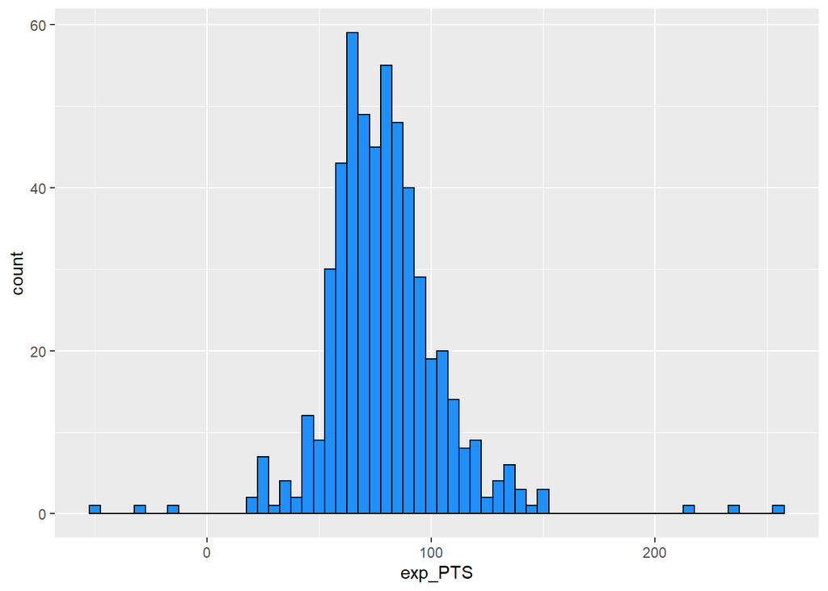

```r
nba_player_stats <- nba_player_stats %>%
  mutate(G1 = MP / team_mins_per_game,
         FG_per_game = FG / G1,
                   x3P_per_game = x3P / G1,
                   x2P_per_game = x2P / G1,
                   FT_per_game = FT / G1,
                   PTS_per_game = PTS / G1,
                   AST_per_game = AST / G1,
                   STL_per_game = STL / G1,
                   BLK_per_game = BLK / G1,
                   ORB_per_game = ORB / G1,
                   DRB_per_game = DRB / G1,
                   TOV_per_game = TOV / G1,
                   PF_per_game = PF / G,1) %>%
  select(-G1)
nba_player_stats <- mutate(nba_player_stats, exp_PTS = predict(fit, newdata = nba_player_stats))

nba_player_stats %>%
  ggplot(aes(x = exp_PTS)) +
  geom_histogram(binwidth = 5, colour = "black", fill = "dodgerblue")
```

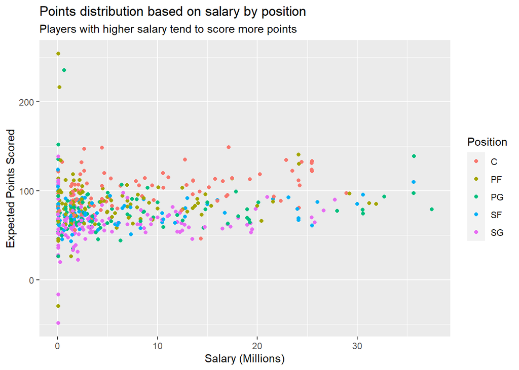

```r
nba_player_stats <- drop_na(nba_player_stats) #removing NA values

gg <- nba_player_stats %>%
  ggplot(aes(x = salary/1000000, y = exp_PTS, color = Pos)) +
  geom_point() +
  xlab("Salary (Millions)") +
  ylab("Expected Points Scored")
gg <- gg +
  labs(title = "Points distribution based on salary by position", subtitle = "Players with higher salary tend to score more points", colour = "Position")
gg
```

```r
gg <- nba_player_stats %>%
  ggplot(aes(x = salary/1000000, y = exp_PTS, color = Pos)) +
  geom_point() +
  xlab("Salary (Millions)") +
  ylab("Expected Points Scored") +
  ylim(90, 260) +
  xlim(0.1, 20)
gg <- gg +
  labs(title = "Points distribution based on salary by position", subtitle = "Players with higher salary tend to score more points", colour = "Position") +
  geom_text(aes(label = player_id), nudge_y = 5)
gg
```

[output not shown]

```r
ggplotly <- gg
ggplotly
```

[output not shown]

### Player Recommendations

Thank you for the opportunity to perform analysis to provide our recommendations on the five starting players for the Chicago Bulls NBA team for the 2019-20 season.

In conducting our analysis, we have assumed that scoring more points is key to winning games. With this assumption in mind, we looked at data both at a team level, and at a player level to see where relationships are between variables and total points scored. Aside from field goals and free throws which have a direct impact on points, we wanted to focus on other key metrics which input to total points. Based on our model, we believe that players who have a high number of assists, defensive rebounds and personal fouls, with a low number of turnovers is key to scoring more points.

1. Shooting Guard Luka Doncic $6,569,040
2. Point Guard Ben Simmons $6,424,520
3. Small Forward Thabo Sefolosha $5,250,000
4. Power Forward Cheick Diallo $1,544,951
5. Centre Pau Gasol $17,133,285

```r
ggplotly
```

[output not shown]

### Summary

The assignment from the General Manager for the Chicago Bulls was to recommend 5 starting players who would fit into the 2019-20 budget of $118,000,000. Based on the analysis completed, we have recommended 5 players who are experts in creating opportunities for scoring through assists, rebounds, and fouls. Intentionally, we did not include field goals in the analysis as this seemed fairly consistent across all teams and the Chicago Bulls did not seem to be performing worse in this area.

There are limitations of the recommendation as we did not look at key variables for each position and have assumed that for all positions, assists, rebounds and fouls are the key metrics. A better approach may have been to conduct separate models for each position, based on the key variables for that position.

### Reference List

1. Wikipedia, the free encyclopedia [wiki on the internet]. St Petersburg (FL): Wikimedia Foundation. 2001 - . Basketball positions; 2021 May 7 [cited 2021 May 9]; [about 5 screens]. Available from: https://en.wikipedia.org/wiki/Basketball_positions
2. Wikipedia, the free encyclopedia [wiki on the internet]. St Petersburg (FL): Wikimedia Foundation. 2001 - . Basketball; 2021 May 7 [cited 2021 May 9]; [about 5 screens]. Available from: https://en.wikipedia.org/wiki/Basketball
3. John. R for Excel users [Internet]. How to remove dollar sign in R (and other currency symbols); 2016 Jun 21 [cited 2021 May 9]; [about 6 screens]. Available from: https://rforexcelusers.com/remove-currency-dollar-sign-r/
4. Ben Bolker. Stack Overflow [Internet]. Consolidate duplicate rows; 2012 Apr 16 [cited 2021 May 9]; [about 6 screens]. Available from: https://stackoverflow.com/questions/10180132/consolidate-duplicate-rows